# Analisi dei Booking degli appartamenti familiari

**Ivona Jelovac**

#### **Obiettivi del proggetto**:

1. **Prenotazioni nel 2024**:
   - Quall' e' il numero di prenotazioni e delle notti occupate
   - Periodi di alta/bassa richiesta.
2. **Confronto tra gli appartamenti**:
   - Qualle appartamento ha più notti occupate?
3. **Provenienza dei clienti, età e genere**
   - Provenienza dei clienti, età e genere e la loro relazione con le notti occupate
4. **Confronto con l'anno 2023**:
   - Quante notti occupate ci sono nell' 2023? Confronto con 2024.

#### **Dataset**:

- dataset privato
- il dataset era stato creato il 18.05.2025.
- periodo coperto: 01/01/2023 - 31/12/2024
- dati disponibili: numero dell' appartamento, date del check-in e check-out, nome, provenienza, età e genere dei clienti

## Prenotazioni nel 2024.

### Quall' e' il numero di prenotazioni e di notti occupate?

#### Numero di appartamenti: 4

#### Numero di prenotazioni: 34

#### Numero di notti occupate: 262

#### Numero di clienti: 92

## Periodi di alta/bassa richiesta

```
Totali notti occupati a giugno 2024: 32
Totali notti occupati a luglio 2024: 83
Totali notti occupati a agosto 2024: 115
Totali notti occupati a settembre 2024: 32
TOTALE: 262

Percentuali:
Giugno: 12.2%
Luglio: 31.7%
Agosto: 43.9%
Settembre: 12.2%
```

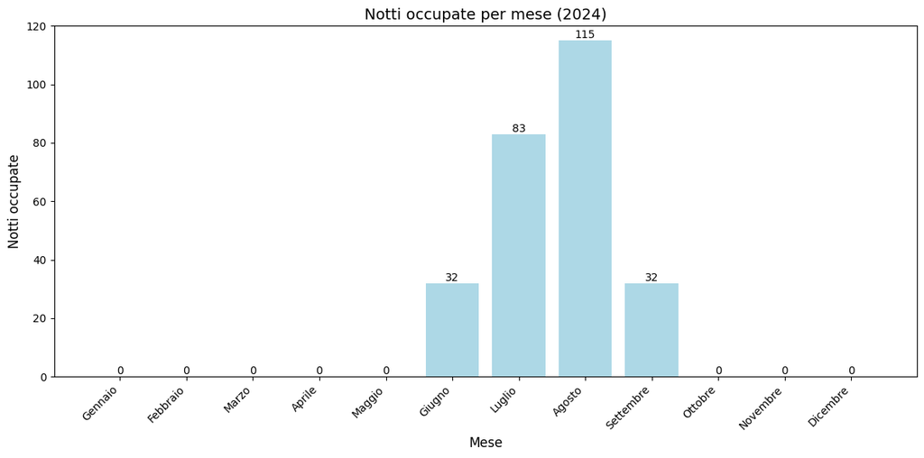

## Confronto tra i 4 appartamenti

```
NOTTI OCCUPATE A GIUGNO 2024 PER APPARTAMENTO:
  Appartamento 1: 3 notti
  Appartamento 2: 7 notti
  Appartamento 3: 11 notti
  Appartamento 4: 11 notti
APPARTAMENTO/I PIÙ OCCUPATO/I A GIUGNO: 3, 4 (11 notti)

NOTTI OCCUPATE A LUGLIO 2024 PER APPARTAMENTO:
  Appartamento 1: 19 notti
  Appartamento 2: 22 notti
  Appartamento 3: 20 notti
  Appartamento 4: 22 notti
APPARTAMENTO/I PIÙ OCCUPATO/I A LUGLIO: 2, 4 (22 notti)

NOTTI OCCUPATE A AGOSTO 2024 PER APPARTAMENTO:
  Appartamento 1: 29 notti
  Appartamento 2: 27 notti
  Appartamento 3: 30 notti
  Appartamento 4: 29 notti
APPARTAMENTO/I PIÙ OCCUPATO/I A AGOSTO: 3 (30 notti)

NOTTI OCCUPATE A SETTEMBRE 2024 PER APPARTAMENTO:
  Appartamento 1: 16 notti
  Appartamento 2: 8 notti
  Appartamento 3: 0 notti
  Appartamento 4: 8 notti
APPARTAMENTO/I PIÙ OCCUPATO/I A SETTEMBRE: 1 (16 notti)
```

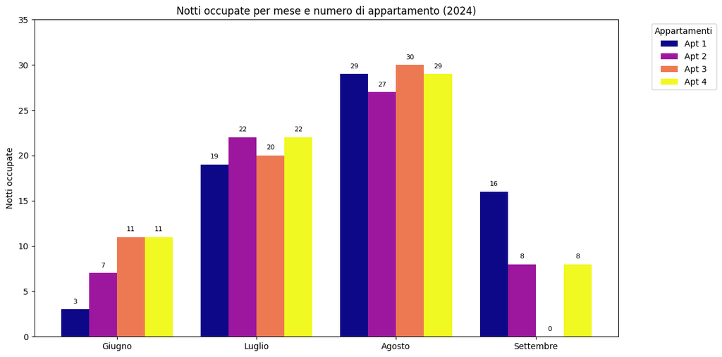

## Provenienza dei clienti, eta' e genere

### a) Provenienza

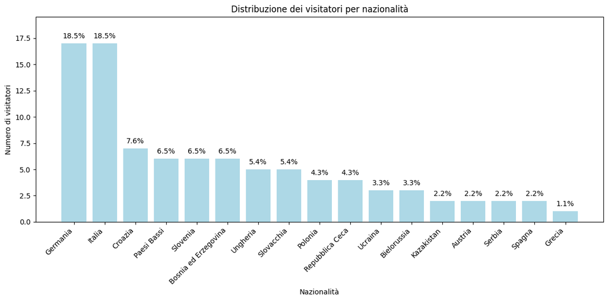

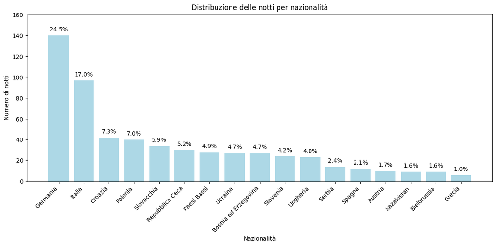

## Provenienza dei clienti, età e genere

### b) Età

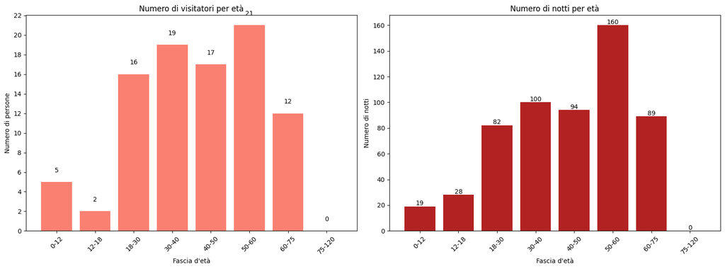

## Provenienza dei clienti, età e genere

### c) Genere

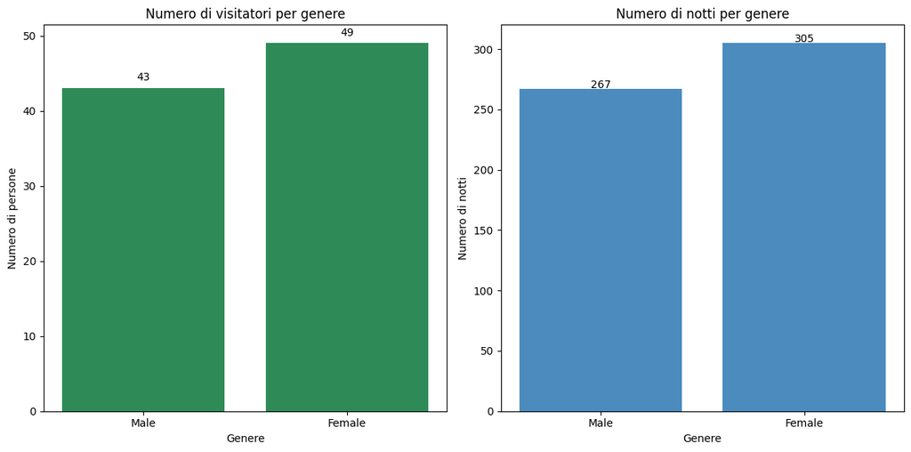

## Confronto con l' anno 2023

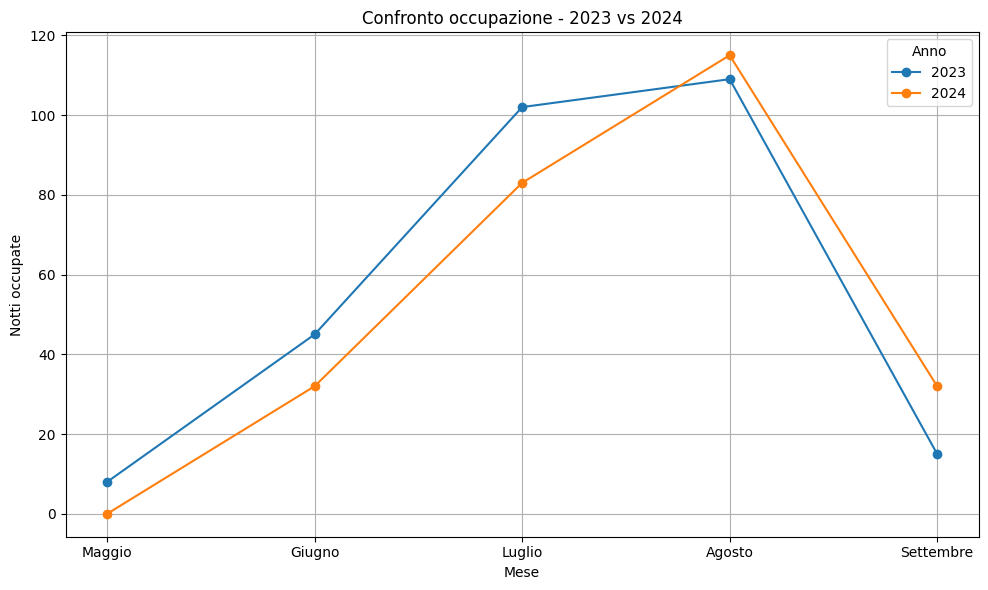

## Conclusione

**1. Stagionalità delle prenotazioni**

**2. Distribuzione tra appartamenti**

Non è stato individuato un appartamento particolarmente preferito.

**3. Nazionalità dei clienti**

I clienti con il maggior numero di prenotazioni sono tedeschi (18.5%) e italiani (18.5%). Tuttavia, i clienti tedeschi hanno un impatto maggiore sulla durata dei soggiorni, occupando il 24.5% delle notti totali, contro il 17.0% degli italiani.

**4. Fasce d’età prevalenti**

La maggior parte degli ospiti rientra nella fascia 50-60 anni (22.8%), seguita da 30-40 anni (20.6%), indicando una prevalenza di turisti di mezza età.

**5. Differenze di genere**

Non si osservano differenze significative nella distribuzione tra generi.

**6. Confronto con l’anno precedente (2023)**

L’analisi non evidenzia grandi variazioni tra il 2023 e il 2024